# GO Analysis

julien.varaldi@univ-lyon1.fr

07/03/2018

# 1 Import data (blast2GO mapping)

```r
blast2GO_mapping=read.table("../output/blast2go_mapping_20180307_0931.txt", sep="\t", header=F, fill = TRUE, comment.char = "", quote = "", skip=1)

dim(blast2GO_mapping)
```

```
## [1] 7991    8
```

```r
names=c("SeqName",  "length",   "bitscore", "eValue",   "hitName"   ,"GOs"  ,"ACC")
names(blast2GO_mapping)=names

# remove last column (empty)
blast2GO_mapping=blast2GO_mapping[,-8]
names(blast2GO_mapping)[1]="locus"
head(blast2GO_mapping)
```

```
##         locus length  bitscore       eValue
## 1 XLOC_000006   9703 1261.8996 0.000000e+00
## 2 XLOC_000006   9703 1261.8996 0.000000e+00
## 3 XLOC_000006   9703 1261.8996 0.000000e+00
## 4 XLOC_000006   9703 1261.8996 0.000000e+00
## 5 XLOC_000011   1358  136.3465 4.990409e-36
## 6 XLOC_000011   1358  136.3465 8.468700e-36
##                                                                                           hitName
## 1                     XP_016773268.1PREDICTED: uncharacterized protein LOC408577 [Apis mellifera]
## 2                        XP_392119.2PREDICTED: uncharacterized protein LOC408577 [Apis mellifera]
## 3                     XP_016773237.1PREDICTED: uncharacterized protein LOC408577 [Apis mellifera]
## 4                     XP_016773222.1PREDICTED: uncharacterized protein LOC408577 [Apis mellifera]
## 5 XP_001946558.2PREDICTED: short stature homeobox protein 2-like isoform X2 [Acyrthosiphon pisum]
## 6 XP_016661060.1PREDICTED: short stature homeobox protein 2-like isoform X1 [Acyrthosiphon pisum]
##                                                                                  GOs
## 1 GO:0035014, GO:0007165, GO:0046872, GO:0043551, GO:0035556, GO:0005942, GO:0005622
## 2 GO:0035014, GO:0046872, GO:0007165, GO:0043551, GO:0035556, GO:0005942, GO:0005622
## 3 GO:0035014, GO:0046872, GO:0007165, GO:0043551, GO:0035556, GO:0005942, GO:0005622
## 4 GO:0035014, GO:0007165, GO:0046872, GO:0043551, GO:0035556, GO:0005942, GO:0005622
## 5             GO:0006979, GO:0004601, GO:0020037, GO:0055114, GO:0098869, GO:0042600
## 6             GO:0006979, GO:0004601, GO:0020037, GO:0055114, GO:0098869, GO:0042600
##              ACC
## 1 XP_016773268.1
## 2    XP_392119.2
## 3 XP_016773237.1
## 4 XP_016773222.1
## 5 XP_001946558.2
## 6 XP_016661060.1
```

```r
# take the first line per locus
liste=split(blast2GO_mapping, f = blast2GO_mapping$locus)
blast2GO_mapping2=lapply(liste, function(x){
  return(x[1,])})
blast2GO_mapping2=do.call(rbind.data.frame,  blast2GO_mapping2 )
head(blast2GO_mapping2)
```

```
##                   locus length   bitscore        eValue
## XLOC_000006 XLOC_000006   9703 1261.89965  0.000000e+00
## XLOC_000011 XLOC_000011   1358  136.34649  4.990409e-36
## XLOC_000013 XLOC_000013   1302  285.03352  1.116420e-73
## XLOC_000014 XLOC_000014    571   97.05613  7.598310e-18
## XLOC_000028 XLOC_000028    644  108.22692  4.740500e-21
## XLOC_000029 XLOC_000029   1344  428.32777 8.579293e-117
##                                                                                                     hitName
## XLOC_000006                     XP_016773268.1PREDICTED: uncharacterized protein LOC408577 [Apis mellifera]
## XLOC_000011 XP_001946558.2PREDICTED: short stature homeobox protein 2-like isoform X2 [Acyrthosiphon pisum]
## XLOC_000013                    XP_001600059.2PREDICTED: neprilysin-11-like isoform X4 [Nasonia vitripennis]
## XLOC_000014                    XP_001600059.2PREDICTED: neprilysin-11-like isoform X4 [Nasonia vitripennis]
## XLOC_000028  XP_016837113.1PREDICTED: uncharacterized protein LOC100678714 isoform X2 [Nasonia vitripennis]
## XLOC_000029                        XP_016844584.1PREDICTED: triosephosphate isomerase [Nasonia vitripennis]
##                                                                                            GOs
## XLOC_000006 GO:0035014, GO:0007165, GO:0046872, GO:0043551, GO:0035556, GO:0005942, GO:0005622
## XLOC_000011             GO:0006979, GO:0004601, GO:0020037, GO:0055114, GO:0098869, GO:0042600
## XLOC_000013                         GO:0016020, GO:0006508, GO:0016021, GO:0008237, GO:0004222
## XLOC_000014                         GO:0016020, GO:0006508, GO:0016021, GO:0008237, GO:0004222
## XLOC_000028                                     GO:0016020, GO:0005509, GO:0016021, GO:0007156
## XLOC_000029 GO:0008152, GO:0006094, GO:0003824, GO:0006098, GO:0006096, GO:0004807, GO:0016853
##                        ACC
## XLOC_000006 XP_016773268.1
## XLOC_000011 XP_001946558.2
## XLOC_000013 XP_001600059.2
## XLOC_000014 XP_001600059.2
## XLOC_000028 XP_016837113.1
## XLOC_000029 XP_016844584.1
```

Complement the table with GO terms (in words, not only code)

```r
#  using the output of BLAST2GO (copy and paste)
blast2GO=read.table("../output/blast2go_go_table_20180307_0943.txt", fill=TRUE,h=T, sep="\t", comment.char = "", quote="")
blast2GO=blast2GO[,-1]
names(blast2GO)=c("status", "locus", "description", "length", "nhits", "evalue", "mean_sim", "nGOs", "GOs", "GOdescription", "enz_code", "enz_name")
# remove last three columns
blast2GO=blast2GO[, -c(dim(blast2GO)[2]:(dim(blast2GO)[2]-2))]
head(blast2GO)
```

```
##                         status       locus
## 1                    [BLASTED] XLOC_000001
## 2                   [NO-BLAST] XLOC_000002
## 3                    [BLASTED] XLOC_000003
## 4                    [BLASTED] XLOC_000004
## 5                   [NO-BLAST] XLOC_000005
## 6 [BLASTED, MAPPED, ANNOTATED] XLOC_000006
##                                                                        description
## 1       XP_011689992.1 RNA-directed DNA polymerase from mobile element jockey-like
## 2                                                                         ---NA---
## 3                  XP_020282573.1protein arginine N-methyltransferase 6 isoform X1
## 4                                XP_016770328.1 transcription factor Sox-21-B-like
## 5                                                                         ---NA---
## 6 XP_011154878.1 phosphatidylinositol 3-kinase regulatory subunit alpha isoform X2
##   length nhits        evalue mean_sim nGOs
## 1    747    20  8.704894e-48    60.05   NA
## 2   6542    NA            NA       NA   NA
## 3   2906    20 3.328588e-115    81.30   NA
## 4   2734    20  4.110266e-75    67.20   NA
## 5    447    NA            NA       NA   NA
## 6   9703    20  0.000000e+00    84.25    6
##                                                                                  GOs
## 1
## 2
## 3
## 4
## 5
## 6 C:GO:0005622; C:GO:0005942; F:GO:0035014; P:GO:0035556; P:GO:0043551; F:GO:0046872
##                                                                                                                                                                                                                    GOdescription
## 1
## 2
## 3
## 4
## 5
## 6 C:intracellular; C:phosphatidylinositol 3-kinase complex; F:phosphatidylinositol 3-kinase regulator activity; P:intracellular signal transduction; P:regulation of phosphatidylinositol 3-kinase activity; F:metal ion binding
##   enz_code enz_name
## 1
## 2
## 3
## 4
## 5
## 6
```

```r
dim(blast2GO)
```

```
## [1] 16679    12
```

```r
blast2GO=merge(blast2GO, blast2GO_mapping2[, c(1,5)], by="locus", all.x=TRUE)
names(blast2GO)=c("locus", "status", "description", "length", "nhits", "evalue", "mean_sim", "nGOs", "GOs", "GOdescription", "enz_code", "enz_name", "hitName")
head(blast2GO)
```

```
##         locus                       status
## 1 XLOC_000001                    [BLASTED]
## 2 XLOC_000002                   [NO-BLAST]
## 3 XLOC_000003                    [BLASTED]
## 4 XLOC_000004                    [BLASTED]
## 5 XLOC_000005                   [NO-BLAST]
## 6 XLOC_000006 [BLASTED, MAPPED, ANNOTATED]
##                                                                        description
## 1       XP_011689992.1 RNA-directed DNA polymerase from mobile element jockey-like
## 2                                                                         ---NA---
## 3                  XP_020282573.1protein arginine N-methyltransferase 6 isoform X1
## 4                                XP_016770328.1 transcription factor Sox-21-B-like
## 5                                                                         ---NA---
## 6 XP_011154878.1 phosphatidylinositol 3-kinase regulatory subunit alpha isoform X2
##   length nhits        evalue mean_sim nGOs
## 1    747    20  8.704894e-48    60.05   NA
## 2   6542    NA            NA       NA   NA
## 3   2906    20 3.328588e-115    81.30   NA
## 4   2734    20  4.110266e-75    67.20   NA
## 5    447    NA            NA       NA   NA
## 6   9703    20  0.000000e+00    84.25    6
##                                                                                  GOs
## 1
## 2
## 3
## 4
## 5
## 6 C:GO:0005622; C:GO:0005942; F:GO:0035014; P:GO:0035556; P:GO:0043551; F:GO:0046872
##                                                                                                                                                                                                                    GOdescription
## 1
## 2
## 3
## 4
## 5
## 6 C:intracellular; C:phosphatidylinositol 3-kinase complex; F:phosphatidylinositol 3-kinase regulator activity; P:intracellular signal transduction; P:regulation of phosphatidylinositol 3-kinase activity; F:metal ion binding
##   enz_code enz_name
## 1
## 2
## 3
## 4
## 5
## 6
##                                                                       hitName
## 1                                                                        <NA>
## 2                                                                        <NA>
## 3                                                                        <NA>
## 4                                                                        <NA>
## 5                                                                        <NA>
## 6 XP_016773268.1PREDICTED: uncharacterized protein LOC408577 [Apis mellifera]
```

Complement the table with expression information

```r
abdo_deseq2=read.table("../output/separate_analysis.abdo.txt", h=T)
head_deseq2=read.table("../output/separate_analysis.head.txt", h=T)
dim(abdo_deseq2)
```

```
## [1] 16679     6
```

```r
dim(head_deseq2)
```

```
## [1] 16679     6
```

```r
deseq2_res=merge(x = abdo_deseq2, y = head_deseq2, by="row.names")
names(deseq2_res)=sub(x = names(deseq2_res) , pattern = "x", replacement = "abdo")
names(deseq2_res)=sub(x = names(deseq2_res) , pattern = "y", replacement = "head")
names(deseq2_res)[1]="locus"
head(deseq2_res)
```

```
##         locus baseMean.abdo log2FoldChange.abdo lfcSE.abdo   stat.abdo
## 1 XLOC_000001      0.118997        -0.089729006  6.1196904 -0.01466234
## 2 XLOC_000002     11.778361         0.258238234  0.7018796  0.36792385
## 3 XLOC_000003    134.848142         0.005459783  0.2466010  0.02214015
## 4 XLOC_000004    176.307726        -0.220392556  0.2003682 -1.09993753
## 5 XLOC_000005      3.566105        -0.398392262  1.2402935 -0.32120805
## 6 XLOC_000006    639.634051         0.050945302  0.1182906  0.43067930
##   pvalue.abdo padj.abdo baseMean.head log2FoldChange.head lfcSE.head
## 1   0.9883016        NA      1.792772          0.78741607 1.58015260
## 2   0.7129300 0.9312650   1421.702627          0.01893922 0.18445903
## 3   0.9823362 0.9965553     22.372850         -0.36964028 0.50285155
## 4   0.2713593 0.7048664    113.041843         -0.27407388 0.29497989
## 5   0.7480527        NA      3.752688          1.27301058 1.20479473
## 6   0.6667016 0.9159721   2081.365276         -0.01078247 0.09963105
##    stat.head pvalue.head padj.head
## 1  0.4983165   0.6182610        NA
## 2  0.1026744   0.9182214 0.9996043
## 3 -0.7350883   0.4622857 0.9996043
## 4 -0.9291274   0.3528231 0.9996043
## 5  1.0566203   0.2906849        NA
## 6 -0.1082240   0.9138180 0.9996043
```

```r
blast2GO2=merge(blast2GO, deseq2_res)
dim(blast2GO2)
```

```
## [1] 16679    25
```

```r
head(blast2GO2)
```

```
##         locus                       status
## 1 XLOC_000001                    [BLASTED]
## 2 XLOC_000002                   [NO-BLAST]
## 3 XLOC_000003                    [BLASTED]
## 4 XLOC_000004                    [BLASTED]
## 5 XLOC_000005                   [NO-BLAST]
## 6 XLOC_000006 [BLASTED, MAPPED, ANNOTATED]
##                                                                        description
## 1       XP_011689992.1 RNA-directed DNA polymerase from mobile element jockey-like
## 2                                                                         ---NA---
## 3                  XP_020282573.1protein arginine N-methyltransferase 6 isoform X1
## 4                                XP_016770328.1 transcription factor Sox-21-B-like
## 5                                                                         ---NA---
## 6 XP_011154878.1 phosphatidylinositol 3-kinase regulatory subunit alpha isoform X2
##   length nhits        evalue mean_sim nGOs
## 1    747    20  8.704894e-48    60.05   NA
## 2   6542    NA            NA       NA   NA
## 3   2906    20 3.328588e-115    81.30   NA
## 4   2734    20  4.110266e-75    67.20   NA
## 5    447    NA            NA       NA   NA
## 6   9703    20  0.000000e+00    84.25    6
##                                                                                  GOs
## 1
## 2
## 3
## 4
## 5
## 6 C:GO:0005622; C:GO:0005942; F:GO:0035014; P:GO:0035556; P:GO:0043551; F:GO:0046872
##                                                                                                                                                                                                                    GOdescription
## 1
## 2
## 3
## 4
## 5
## 6 C:intracellular; C:phosphatidylinositol 3-kinase complex; F:phosphatidylinositol 3-kinase regulator activity; P:intracellular signal transduction; P:regulation of phosphatidylinositol 3-kinase activity; F:metal ion binding
##   enz_code enz_name
## 1
## 2
## 3
## 4
```

[output cut: 15 more lines]

```
## 6    639.634051         0.050945302  0.1182906  0.43067930   0.6667016
##   padj.abdo baseMean.head log2FoldChange.head lfcSE.head  stat.head
## 1        NA      1.792772          0.78741607 1.58015260  0.4983165
## 2 0.9312650   1421.702627          0.01893922 0.18445903  0.1026744
## 3 0.9965553     22.372850         -0.36964028 0.50285155 -0.7350883
## 4 0.7048664    113.041843         -0.27407388 0.29497989 -0.9291274
## 5        NA      3.752688          1.27301058 1.20479473  1.0566203
## 6 0.9159721   2081.365276         -0.01078247 0.09963105 -0.1082240
##   pvalue.head padj.head
## 1   0.6182610        NA
## 2   0.9182214 0.9996043
## 3   0.4622857 0.9996043
## 4   0.3528231 0.9996043
## 5   0.2906849        NA
## 6   0.9138180 0.9996043
```

Import the list of candidate genes

```r
candidates_abdo_up=read.table("../output/candidates_abdo_up_final.txt", h=F)
candidates_abdo_down=read.table("../output/candidates_abdo_down_final.txt", h=F)
candidates_head_up=read.table("../output/candidates_head_up_final.txt", h=F)
candidates_head_down=read.table("../output/candidates_head_down_final.txt", h=F)
candidates_abdo=c(as.character(candidates_abdo_up$V1), as.character(candidates_abdo_down$V1))
candidates_head=c(as.character(candidates_head_up$V1), as.character(candidates_head_down$V1))
```

Write a fasta file with candidate sequences

```r
sequ=readDNAStringSet("../data/transcripts_one_per_gene.fa")
prot=readAAStringSet("../data/longest_orfs.pep")
length(sequ)
```

```
## [1] 16679
```

```r
length(prot)
```

```
## [1] 18251
```

```r
# subset to candidates abdo
names_seq=lapply(strsplit(names(x = sequ), split = " ", fixed = T), FUN=function(x) {return(x[1])})
names(sequ)=unlist(names_seq)
seq_abdo=sequ[which(names(sequ) %in% candidates_abdo)]
length(seq_abdo)
```

```
## [1] 135
```

```r
# prot
names_seq_prot=lapply(strsplit(names(x = prot), split = ".", fixed = T), FUN=function(x) {return(x[1])})
liste=split(data.frame(names(prot),unlist(names_seq_prot)), f = unlist(names_seq_prot))
longest_orf=lapply(X = liste, FUN = function(x){
  res=x[1,1]
  return(res)
})
prot2=prot[which(names(prot) %in% unlist(longest_orf))]
# extract locus name
names_seq_prot2=lapply(strsplit(names(x = prot2), split = ".", fixed = T), FUN=function(x) {return(x[1])})
names(prot2)=unlist(names_seq_prot2)
seq_abdo_prot=prot2[which(names(prot2) %in% candidates_abdo)]
length(seq_abdo_prot)
```

```
## [1] 110
```

```r
# subset to candidates head
seq_head=sequ[which(names(sequ) %in% candidates_head)]
length(seq_head)
```

```
## [1] 18
```

```r
# prot
seq_head_prot=prot2[which(names(prot2) %in% candidates_head)]
length(seq_head_prot)
```

```
## [1] 11
```

```r
writeXStringSet(seq_abdo, filepath = "../output/candidates_abdo.fasta")
writeXStringSet(seq_head, filepath = "../output/candidates_head.fasta")

writeXStringSet(seq_abdo_prot, filepath = "../output/candidates_abdo_AA.fasta")
writeXStringSet(seq_head_prot, filepath = "../output/candidates_head_AA.fasta")
```

Write a table with blast2GO and expression info for candidate genes

```r
blast2GO_abdo_DE=blast2GO2[which(blast2GO2$locus %in% candidates_abdo),]
blast2GO_head_DE=blast2GO2[which(blast2GO2$locus %in% candidates_head),]

write.table(x = blast2GO_abdo_DE, file = "../output/DE_abdo_annotated_blast2GO.txt", quote = FALSE, row.names = FALSE, sep="\t")
write.table(x = blast2GO_head_DE, file = "../output/DE_head_annotated_blast2GO.txt", quote = FALSE, row.names = FALSE, sep="\t")
```

# 2 GO analysis

## 2.1 Procedure of annotation

We will follow the procedure described here *http://www-huber.embl.de/users/klaus/Teaching/DESeq2Predoc2014.html#gene-ontology-enrichment-analysis*

using the library topGO.

We then check whether the background has roughly the same distribution of average expression strength as the foreground by plotting the densities.

We do this in order not to select a biased background since the gene set testing is performed by a simple Fisher test on a 2x2 table, which uses only the status of a gene, i.e. whether it is differentially expressed or not and not its fold–change or absolute expression.

Note that the chance of a gene being identified as DE will most probably depend on its gene expression for RNA–Seq data (potentially also its gene length etc.). Thus it is important to find a matching background. Our testing approach here is very similar to web tools like DAVID, however, we explicitly model the background here.

We first get average gene expressions for each of the genes and then find non–DE genes that show a similar expression as the DE–genes. These genes are then our background.

## 2.2 Get a list of GO per locus

```r
blast2GO_mapping_split=split(x = blast2GO2, f = blast2GO2$locus)

geneID2GO=lapply(blast2GO_mapping_split, FUN = function(x){

  GOs=strsplit(as.character(x$GOs), split = ";", fixed = T)

  GOs=lapply(GOs, FUN = function(x) {
    res=sub(pattern = "C:", replacement = "" , x = x)
    res=sub(pattern = "P:", replacement = "" , x = res)
    res=sub(pattern = "F:", replacement = "" , x = res)
    return(res)
    })

  GOs=unlist(GOs)
  GOs=unique(GOs)
  return(GOs)
})

# just a test

GO2geneID <- inverseList(geneID2GO)
str(head(GO2geneID))
```

```
## List of 6
##  $  GO:0000056: chr "XLOC_014784"
##  $  GO:0000122: chr "XLOC_014784"
##  $  GO:0000166: chr "XLOC_006178"
##  $  GO:0000287: chr [1:2] "XLOC_007514" "XLOC_013009"
##  $  GO:0000380: chr "XLOC_008361"
##  $  GO:0000395: chr "XLOC_008361"
```

## 2.3 identify background genes for abdomen

```r
overallBaseMean <- as.matrix(blast2GO2[, "baseMean.abdo", drop = F])

sig_idx = which(blast2GO2$locus %in% candidates_abdo)

backG_abdo <- c()

for(i in sig_idx){
  ind <- genefinder(overallBaseMean, i, 20, method = "manhattan")[[1]]$indices
  backG_abdo <- c(backG_abdo, ind)
  }

backG_abdo <- unique(backG_abdo)
backG_abdo <- blast2GO2$locus[backG_abdo]

# remove DE from background genes
backG_abdo <- setdiff(backG_abdo,  sig_idx)
length(backG_abdo)
```

```
## [1] 2302
```

```r
backG_abdo_index=which(blast2GO2$locus %in% backG_abdo)
```

Plotting the density of the average expressions, shows that the background matching has worked reasonably well.

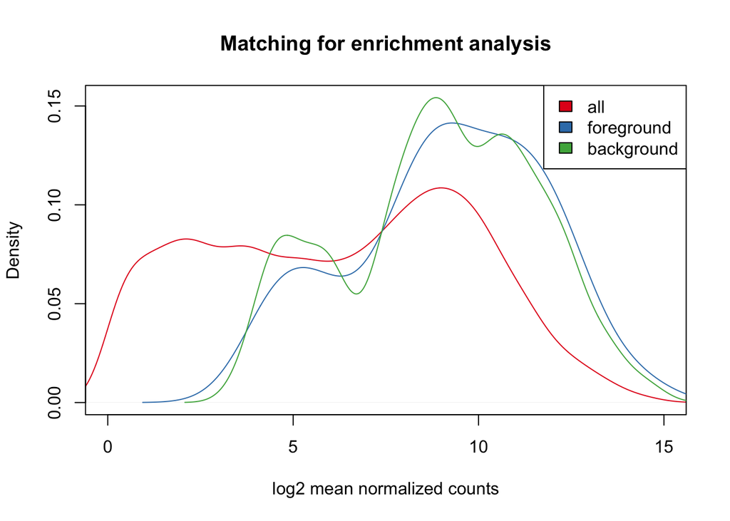

```r
  multidensity( list(
       all= log2(blast2GO2[,"baseMean.abdo"]) ,
       foreground =log2(blast2GO2[sig_idx, "baseMean.abdo"]),
       background =log2(blast2GO2[backG_abdo_index, "baseMean.abdo"])),
     xlab="log2 mean normalized counts", main = "Matching for enrichment analysis", xlim=c(0,15))
```

## 2.4 Identify background selection genes for head

```r
overallBaseMean <- as.matrix(blast2GO2[, "baseMean.head", drop = F])

sig_idx = which(blast2GO2$locus %in% candidates_head)

backG_head <- c()

for(i in sig_idx){
  ind <- genefinder(overallBaseMean, i, 20, method = "manhattan")[[1]]$indices
  backG_head <- c(backG_head, ind)
  }

backG_head <- unique(backG_head)
backG_head <- blast2GO2$locus[backG_head]

# remove DE from background genes
backG_head <- setdiff(backG_head,  sig_idx)
length(backG_head)
```

```
## [1] 360
```

```r
backG_head_index=which(blast2GO2$locus %in% backG_head)
```

Plotting the density of the average expressions, shows that the background matching has worked reasonably well.

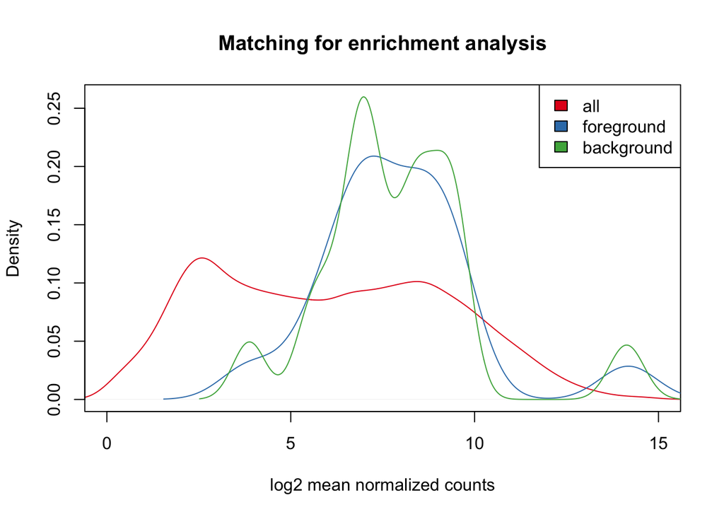

```r
  multidensity( list(
       all= log2(blast2GO2[,"baseMean.head"]) ,
       foreground =log2(blast2GO2[sig_idx, "baseMean.head"]),
       background =log2(blast2GO2[backG_head_index, "baseMean.head"])),
     xlab="log2 mean normalized counts", main = "Matching for enrichment analysis", xlim=c(0,15))
```

We can now perform the actual testing. For this purpose we use the package which implements a nice interface to the Fisher–test based enrichment testing and also has additional algorithms taking the GO structure into account, by e.g. only reporting the most specific gene set in the hierarchy. For more details, see the paper:Alexa et. al. – Improved scoring of functional groups from gene expression data by decorrelating GO graph structure - Bioinformatics, 2006.

## 2.5 GO enrichment analysis for transcripts specifically DE in the abdomen

```r
# using the p-value score
geneList_abdo_bg=blast2GO2[blast2GO2$locus %in% backG_abdo,c("locus","padj.abdo")]
geneList_abdo_DE=blast2GO2[blast2GO2$locus %in% candidates_abdo,c("locus","padj.abdo")]
geneList_abdo_tot=rbind(geneList_abdo_bg, geneList_abdo_DE)
geneList_abdo =   geneList_abdo_tot$padj.abdo
names(geneList_abdo)=geneList_abdo_tot$locus
str(object = geneList_abdo)
```

```
##  Named num [1:2437] 0.78 0.934 0.972 0.516 0.987 ...
##  - attr(*, "names")= chr [1:2437] "XLOC_000008" "XLOC_000018" "XLOC_000048" "XLOC_000052" ...
```

testing

```r
# we define a rule for designing significant genes
topDiffGenes <- function(allScore) {
  return(allScore < 0.05)
}

GOdata_abdo <- new("topGOdata",
                   description = "GO analysis of Abdomen based on adjusted p-values",
                   ontology = "MF",
                   allGenes = geneList_abdo,
                   geneSel = topDiffGenes,
                   annot = annFUN.gene2GO,
                   gene2GO = geneID2GO,
                   nodeSize = 7)
```

```
##
## Building most specific GOs .....
```

```
##  ( 157 GO terms found. )
```

```
##
## Build GO DAG topology ..........
```

```
##  ( 366 GO terms and 446 relations. )
```

```
##
## Annotating nodes ...............
```

```
##  ( 495 genes annotated to the GO terms. )
```

```r
resultFisher_abdo_classic <- runTest(GOdata_abdo, algorithm = "classic", statistic = "fisher")
```

```
##
##           -- Classic Algorithm --
##
##       the algorithm is scoring 52 nontrivial nodes
##       parameters:
##           test statistic: fisher
```

```r
resultFisher_abdo_weigth01 <- runTest(GOdata_abdo, algorithm = "weight01", statistic = "fisher")
```

```
##
##           -- Weight01 Algorithm --
##
##       the algorithm is scoring 52 nontrivial nodes
##       parameters:
##           test statistic: fisher
```

```
##
##   Level 9:   2 nodes to be scored    (0 eliminated genes)
```

```
##
##   Level 8:   2 nodes to be scored    (0 eliminated genes)
```

```
##
##   Level 7:   5 nodes to be scored    (44 eliminated genes)
```

```
##
##   Level 6:   6 nodes to be scored    (44 eliminated genes)
```

```
##
##   Level 5:   10 nodes to be scored   (68 eliminated genes)
```

```
##
##   Level 4:   8 nodes to be scored    (89 eliminated genes)
```

```
##
##   Level 3:   13 nodes to be scored   (226 eliminated genes)
```

```
##
##   Level 2:   5 nodes to be scored    (272 eliminated genes)
```

```
##
##   Level 1:   1 nodes to be scored    (427 eliminated genes)
```

```r
resultFisher_abdo_elim <- runTest(GOdata_abdo, algorithm = "elim", statistic = "fisher")
```

```
##
##           -- Elim Algorithm --
##
##       the algorithm is scoring 52 nontrivial nodes
##       parameters:
##           test statistic: fisher
##           cutOff: 0.01
```

```
##
##   Level 9:   2 nodes to be scored    (0 eliminated genes)
```

```
##
##   Level 8:   2 nodes to be scored    (0 eliminated genes)
```

```
##
##   Level 7:   5 nodes to be scored    (0 eliminated genes)
```

```
##
##   Level 6:   6 nodes to be scored    (0 eliminated genes)
```

```
##
##   Level 5:   10 nodes to be scored   (0 eliminated genes)
```

```
##
##   Level 4:   8 nodes to be scored    (0 eliminated genes)
```

```
##
##   Level 3:   13 nodes to be scored   (0 eliminated genes)
```

```
##
##   Level 2:   5 nodes to be scored    (0 eliminated genes)
```

```
##
##   Level 1:   1 nodes to be scored    (0 eliminated genes)
```

```r
resultFisher_abdo_weight <- runTest(GOdata_abdo, algorithm = "weight", statistic = "fisher")
```

```
##
##           -- Weight Algorithm --
##
##       The algorithm is scoring 52 nontrivial nodes
##       parameters:
##           test statistic: fisher : ratio
```

```
##
##   Level 9:   2 nodes to be scored.
```

```
##
##   Level 8:   2 nodes to be scored.
```

```
##
##   Level 7:   5 nodes to be scored.
```

```
##
##   Level 6:   6 nodes to be scored.
```

```
##
##   Level 5:   10 nodes to be scored.
```

```
##
##   Level 4:   8 nodes to be scored.
```

```
##
##   Level 3:   13 nodes to be scored.
```

```
##
##   Level 2:   5 nodes to be scored.
```

```
##
##   Level 1:   1 nodes to be scored.
```

```r
resultFisher_abdo_parentchild <- runTest(GOdata_abdo, algorithm = "parentchild", statistic = "fisher")
```

```
##
##           -- Parent-Child Algorithm --
##
##       the algorithm is scoring 52 nontrivial nodes
##       parameters:
##           test statistic: fisher : joinFun = union
```

```
##
##   Level 9:   2 nodes to be scored.
```

```
##
##   Level 8:   2 nodes to be scored.
```

```
##
##   Level 7:   5 nodes to be scored.
```

```
##
##   Level 6:   6 nodes to be scored.
```

```
##
##   Level 5:   10 nodes to be scored.
```

```
##
##   Level 4:   8 nodes to be scored.
```

```
##
##   Level 3:   13 nodes to be scored.
```

```
##
##   Level 2:   5 nodes to be scored.
```

```r
# significant ones:
score(resultFisher_abdo_classic)[score(resultFisher_abdo_classic)<0.05]
```

```
## named numeric(0)
```

```r
score(resultFisher_abdo_weigth01)[score(resultFisher_abdo_weigth01)<0.05]
```

```
## named numeric(0)
```

```r
score(resultFisher_abdo_elim)[score(resultFisher_abdo_elim)<0.05]
```

```
## named numeric(0)
```

```r
score(resultFisher_abdo_weight)[score(resultFisher_abdo_weight)<0.05]
```

```
## named numeric(0)
```

```r
score(resultFisher_abdo_parentchild)[score(resultFisher_abdo_parentchild)<0.05]
```

```
## named numeric(0)
```

No enrichment

## 2.6 GO enrichment analysis for transcripts specifically DE in the head

```r
# using the p-value score
geneList_head_bg=blast2GO2[blast2GO2$locus %in% backG_head,c("locus","padj.head")]
geneList_head_DE=blast2GO2[blast2GO2$locus %in% candidates_head,c("locus","padj.head")]
geneList_head_tot=rbind(geneList_head_bg, geneList_head_DE)
geneList_head =   geneList_head_tot$padj.head
names(geneList_head)=geneList_head_tot$locus
str(object = geneList_head)
```

```
##  Named num [1:378] 0.432 1 1 1 1 ...
##  - attr(*, "names")= chr [1:378] "XLOC_000032" "XLOC_000062" "XLOC_000099" "XLOC_000107" ...
```

testing

```r
# we define a rule for designing significant genes
topDiffGenes <- function(allScore) {
  return(allScore < 0.05)
}

GOdata_head <- new("topGOdata",
                   description = "GO analysis of head based on adjusted p-values",
                   ontology = "MF",
                   allGenes = geneList_head,
                   geneSel = topDiffGenes,
                   annot = annFUN.gene2GO,
                   gene2GO = geneID2GO,
                   nodeSize = 7)
```

```
##
## Building most specific GOs .....
```

```
##  ( 44 GO terms found. )
```

```
##
## Build GO DAG topology ..........
```

```
##  ( 142 GO terms and 174 relations. )
```

```
##
## Annotating nodes ...............
```

```
##  ( 72 genes annotated to the GO terms. )
```

```r
resultFisher_head_classic <- runTest(GOdata_head, algorithm = "classic", statistic = "fisher")
```

```
##
##           -- Classic Algorithm --
##
##       the algorithm is scoring 6 nontrivial nodes
##       parameters:
##           test statistic: fisher
```

```r
resultFisher_head_weigth01 <- runTest(GOdata_head, algorithm = "weight01", statistic = "fisher")
```

```
##
##           -- Weight01 Algorithm --
##
##       the algorithm is scoring 6 nontrivial nodes
##       parameters:
##           test statistic: fisher
```

```
##
##   Level 5:   1 nodes to be scored    (0 eliminated genes)
```

```
##
##   Level 4:   1 nodes to be scored    (0 eliminated genes)
```

```
##
##   Level 3:   1 nodes to be scored    (8 eliminated genes)
```

```
##
##   Level 2:   2 nodes to be scored    (8 eliminated genes)
```

```
##
##   Level 1:   1 nodes to be scored    (8 eliminated genes)
```

```r
resultFisher_head_elim <- runTest(GOdata_head, algorithm = "elim", statistic = "fisher")
```

```
##
##           -- Elim Algorithm --
##
##       the algorithm is scoring 6 nontrivial nodes
##       parameters:
##           test statistic: fisher
##           cutOff: 0.01
```

```
##
##   Level 5:   1 nodes to be scored    (0 eliminated genes)
```

```
##
##   Level 4:   1 nodes to be scored    (0 eliminated genes)
```

```
##
##   Level 3:   1 nodes to be scored    (0 eliminated genes)
```

```
##
##   Level 2:   2 nodes to be scored    (0 eliminated genes)
```

```
##
##   Level 1:   1 nodes to be scored    (0 eliminated genes)
```

```r
resultFisher_head_weight <- runTest(GOdata_head, algorithm = "weight", statistic = "fisher")
```

```
##
##           -- Weight Algorithm --
##
##       The algorithm is scoring 6 nontrivial nodes
##       parameters:
##           test statistic: fisher : ratio
```

```
##
##   Level 5:   1 nodes to be scored.
```

```
##
##   Level 4:   1 nodes to be scored.
```

```
##
##   Level 3:   1 nodes to be scored.
```

```
##
##   Level 2:   2 nodes to be scored.
```

```
##
##   Level 1:   1 nodes to be scored.
```

```r
resultFisher_head_parentchild <- runTest(GOdata_head, algorithm = "parentchild", statistic = "fisher")
```

```
##
##           -- Parent-Child Algorithm --
##
##       the algorithm is scoring 6 nontrivial nodes
##       parameters:
##           test statistic: fisher : joinFun = union
```

```
##
##   Level 5:   1 nodes to be scored.
```

```
##
##   Level 4:   1 nodes to be scored.
```

```
##
##   Level 3:   1 nodes to be scored.
```

```
##
##   Level 2:   2 nodes to be scored.
```

```r
# significant ones:
score(resultFisher_head_classic)[score(resultFisher_head_classic)<0.05]
```

```
## named numeric(0)
```

```r
score(resultFisher_head_weigth01)[score(resultFisher_head_weigth01)<0.05]
```

```
## named numeric(0)
```

```r
score(resultFisher_head_elim)[score(resultFisher_head_elim)<0.05]
```

```
## named numeric(0)
```

```r
score(resultFisher_head_weight)[score(resultFisher_head_weight)<0.05]
```

```
## named numeric(0)
```

```r
score(resultFisher_head_parentchild)[score(resultFisher_head_parentchild)<0.05]
```

```
## named numeric(0)
```

No enrichment

# 3 Add pfam domains to the annotation

Search pfam db for each sequence

```bash
#PBS -S /bin/bash
#PBS -e /pandata/varaldi/RNAseq_fev2018_cuffmerge/logs/PFAM.error
#PBS -o /pandata/varaldi/RNAseq_fev2018_cuffmerge/logs/PFAM.out
#PBS -N PFAM
#PBS -l nodes=1:ppn=4 -l mem=10gb
#PBS -q q1day
hostname
uname -a
TRANSDECODER1=~/TOOLS/TransDecoder-TransDecoder-v5.0.2/TransDecoder.LongOrfs
TRANSDECODER2=~/TOOLS/TransDecoder-TransDecoder-v5.0.2/TransDecoder.Predict
OUT=/pandata/varaldi/RNAseq_fev2018/MERGE/PFAM
TRANSCRIPTS=/pandata/varaldi/RNAseq_fev2018/MERGE/transcripts_one_per_gene.fa
PFAM=/pandata/varaldi/PFAM/Pfam-A.hmm

# obtain longest orfs
$TRANSDECODER1 -t $TRANSCRIPTS

# search pfam db
cd *.transdecoder_dir
/usr/bin/hmmscan --cpu 4 -E 0.001 --tblout table.pfma.out --domtblout pfam.domtblout $PFAM longest_orfs.pep

mv ./* $OUT
```

## 3.1 import data

```r
pfam=read.table("../data/table.pfma.out2", sep = "", h=F, fill=T, comment.char = "",  encoding = "UTF8",flush = T)
dim(pfam)
```

```
## [1] 23454    23
```

```r
# several domains may be found per sequence

head(pfam)
```

```
##              V1         V2        V3 V4      V5    V6   V7      V8    V9
## 1       DUF4419  PF14388.5   ORF1.p1  - 4.5e-45 154.3  2.0 6.8e-45 153.7
## 2        MSV199  PF10553.8 ORF101.p1  - 4.9e-05  23.5  5.9 4.9e-05  23.5
## 3 Peptidase_M10 PF00413.23 ORF104.p1  - 2.1e-06  27.5  0.1 2.6e-06  27.3
## 4       DUF4953  PF16313.4 ORF104.p1  - 1.7e-04  20.8  0.0 2.4e-04  20.3
## 5 Peptidase_M66  PF10462.8 ORF104.p1  - 3.3e-04  19.6  0.2 5.0e-04  19.0
## 6    zf-C3HC4_3  PF13920.5 ORF105.p1  - 3.3e-05  23.5 11.0 8.3e-05  22.3
##    V10 V11 V12 V13 V14 V15 V16 V17 V18        V19     V20     V21      V22
## 1  2.0 1.3   1   0   0   1   1   1   1     Domain      of unknown function
## 2  5.9 4.4   1   1   1   3   3   3   2     MSV199  domain
## 3  0.1 1.4   1   1   0   1   1   1   1   Matrixin
## 4  0.0 1.2   1   0   0   1   1   1   1 Met-zincin
## 5  0.2 1.2   1   0   0   1   1   1   1  Peptidase     M66
## 6 11.0 1.7   1   0   0   1   1   1   1       Zinc finger,   C3HC4     type
##         V23
## 1 (DUF4419)
## 2
## 3
## 4
## 5
## 6     (RING
```

```r
# create a last column with description
description_of_target = paste(pfam$V19, pfam$V20, pfam$V21, pfam$V22, pfam$V23, sep = "_")
description_of_target = gsub(x = as.character(description_of_target), pattern = "_____", replacement = "")
description_of_target = gsub(x = as.character(description_of_target), pattern = "____", replacement = "")
description_of_target = gsub(x = as.character(description_of_target), pattern = "___", replacement = "")
description_of_target = gsub(x = as.character(description_of_target), pattern = "__", replacement = "")
description_of_target = gsub(x = as.character(description_of_target), pattern = "_", replacement = " ")
head(description_of_target)
```

```
## [1] "Domain of unknown function (DUF4419)"
## [2] "MSV199 domain"
## [3] "Matrixin"
## [4] "Met-zincin"
## [5] "Peptidase M66"
## [6] "Zinc finger, C3HC4 type (RING"
```

```r
pfam=data.frame(pfam[, 1:18], description_of_target)
names=c("target_name","accession" ,"query_name",  "accession2",    "E-value",  "score",  "bias",   "E-value",  "score",  "bias",   "exp", "reg", "clu",  "ov", "env", "dom", "rep", "inc", "description of target")
names(pfam)=names

# parse locus name
locus=unlist(lapply(strsplit(as.character(pfam$query_name), split = ".", fixed = T), FUN=function(x) {return(x[1])}))
pfam=data.frame(locus, pfam[,-c(3:4)])

head(pfam)
```

```
##    locus   target_name  accession E.value score bias E.value.1 score.1
## 1   ORF1       DUF4419  PF14388.5 4.5e-45 154.3  2.0   6.8e-45   153.7
## 2 ORF101        MSV199  PF10553.8 4.9e-05  23.5  5.9   4.9e-05    23.5
## 3 ORF104 Peptidase_M10 PF00413.23 2.1e-06  27.5  0.1   2.6e-06    27.3
## 4 ORF104       DUF4953  PF16313.4 1.7e-04  20.8  0.0   2.4e-04    20.3
## 5 ORF104 Peptidase_M66  PF10462.8 3.3e-04  19.6  0.2   5.0e-04    19.0
## 6 ORF105    zf-C3HC4_3  PF13920.5 3.3e-05  23.5 11.0   8.3e-05    22.3
##   bias.1 exp reg clu ov env dom rep inc
## 1    2.0 1.3   1   0  0   1   1   1   1
## 2    5.9 4.4   1   1  1   3   3   3   2
## 3    0.1 1.4   1   1  0   1   1   1   1
## 4    0.0 1.2   1   0  0   1   1   1   1
## 5    0.2 1.2   1   0  0   1   1   1   1
## 6   11.0 1.7   1   0  0   1   1   1   1
##                  description.of.target
## 1 Domain of unknown function (DUF4419)
## 2                        MSV199 domain
## 3                             Matrixin
## 4                           Met-zincin
## 5                        Peptidase M66
## 6        Zinc finger, C3HC4 type (RING
```

prepare a list of domains per locus and merge with blast2GO and expression data.

```r
liste=split(x = pfam, f = pfam$locus)
# number of genes with identified dominain(s)
length(liste)
```

```
## [1] 8712
```

```r
liste2=lapply(X = liste, FUN=function(x){
  pfam_target_name=paste(x$target_name, collapse = "/")
  pfam_accession=paste(x$accession, collapse = "/")
  pfam_evalue=paste(x$E.value, collapse = "/")
  pfam_description=paste(x$description.of.target, collapse = "/")
  locus=x$locus[1]
  res=data.frame(locus, pfam_target_name,pfam_accession, pfam_evalue, pfam_description )
  return(res)
})

domains_per_sequence=do.call(rbind.data.frame, liste2)
head(domains_per_sequence)
```

```
##         locus                    pfam_target_name
## ORF1     ORF1                             DUF4419
## ORF101 ORF101                              MSV199
## ORF104 ORF104 Peptidase_M10/DUF4953/Peptidase_M66
## ORF105 ORF105                          zf-C3HC4_3
## ORF106 ORF106                Lyase_8_N/Baculo_E66
## ORF11   ORF11                                JmjC
##                        pfam_accession             pfam_evalue
## ORF1                        PF14388.5                 4.5e-45
## ORF101                      PF10553.8                 4.9e-05
## ORF104 PF00413.23/PF16313.4/PF10462.8 2.1e-06/0.00017/0.00033
## ORF105                      PF13920.5                 3.3e-05
## ORF106          PF08124.10/PF04850.11           8.2e-11/1e-04
## ORF11                      PF02373.21                 1.3e-09
##                                                                         pfam_description
## ORF1                                                Domain of unknown function (DUF4419)
## ORF101                                                                     MSV199 domain
## ORF104                                                 Matrixin/Met-zincin/Peptidase M66
## ORF105                                                     Zinc finger, C3HC4 type (RING
## ORF106 Polysaccharide lyase family 8, N/Baculovirus E66 occlusion-derived virus envelope
## ORF11                                                           JmjC domain, hydroxylase
```

```r
# merge with blast2GO and expression information
final_tab=merge(blast2GO2, domains_per_sequence, all.x=T)

# reorder columns
final_tab=final_tab[, c(1,3:12, 26:29, 14:25)]
head(final_tab)
```

```
##         locus
## 1 XLOC_000001
## 2 XLOC_000002
## 3 XLOC_000003
## 4 XLOC_000004
## 5 XLOC_000005
## 6 XLOC_000006
##                                                                        description
## 1       XP_011689992.1 RNA-directed DNA polymerase from mobile element jockey-like
## 2                                                                         ---NA---
## 3                  XP_020282573.1protein arginine N-methyltransferase 6 isoform X1
## 4                                XP_016770328.1 transcription factor Sox-21-B-like
## 5                                                                         ---NA---
## 6 XP_011154878.1 phosphatidylinositol 3-kinase regulatory subunit alpha isoform X2
##   length nhits        evalue mean_sim nGOs
## 1    747    20  8.704894e-48    60.05   NA
## 2   6542    NA            NA       NA   NA
## 3   2906    20 3.328588e-115    81.30   NA
## 4   2734    20  4.110266e-75    67.20   NA
## 5    447    NA            NA       NA   NA
## 6   9703    20  0.000000e+00    84.25    6
##                                                                                  GOs
## 1
## 2
## 3
## 4
## 5
## 6 C:GO:0005622; C:GO:0005942; F:GO:0035014; P:GO:0035556; P:GO:0043551; F:GO:0046872
##                                                                                                                                                                                                                    GOdescription
## 1
## 2
## 3
## 4
## 5
## 6 C:intracellular; C:phosphatidylinositol 3-kinase complex; F:phosphatidylinositol 3-kinase regulator activity; P:intracellular signal transduction; P:regulation of phosphatidylinositol 3-kinase activity; F:metal ion binding
##   enz_code enz_name
## 1
## 2
## 3
## 4
```

[output cut: 36 more lines]

```
## 6    639.634051         0.050945302  0.1182906  0.43067930   0.6667016
##   padj.abdo baseMean.head log2FoldChange.head lfcSE.head  stat.head
## 1        NA      1.792772          0.78741607 1.58015260  0.4983165
## 2 0.9312650   1421.702627          0.01893922 0.18445903  0.1026744
## 3 0.9965553     22.372850         -0.36964028 0.50285155 -0.7350883
## 4 0.7048664    113.041843         -0.27407388 0.29497989 -0.9291274
## 5        NA      3.752688          1.27301058 1.20479473  1.0566203
## 6 0.9159721   2081.365276         -0.01078247 0.09963105 -0.1082240
##   pvalue.head padj.head
## 1   0.6182610        NA
## 2   0.9182214 0.9996043
## 3   0.4622857 0.9996043
## 4   0.3528231 0.9996043
## 5   0.2906849        NA
## 6   0.9138180 0.9996043
```

```r
dim(final_tab)
```

```
## [1] 16679    27
```

# 4 Correlation with the phenotype

Correlate the level of transcriptomic change with the phenotype

```r
log2fold_head=read.table("../output/Log2Fold_head.txt")
log2fold_abdo=read.table("../output/Log2Fold_abdo.txt")
phenotypes=read.table("../data/phenotype.txt", h=T)
phenotypes=phenotypes$tabms.avg[phenotypes$Infection_status=="Inf"]


correlation_function=function(table=log2fold_head, phenotypes=phenotypes){
  res=NULL

  for (i in 1:dim(table)[1]){
    log2fold=table[i,]
    if (sum(is.na(log2fold))==0){
    test=cor.test(t(log2fold),phenotypes)
    res2=c(test$statistic, test$p.value)
    res=rbind(res,res2)
    }
    if (sum(is.na(log2fold))>0)
    {
      res2=c(NA, NA)
      res=rbind(res,res2)
    }
  }
  res=as.data.frame(res)
  names(res)=c("t", "p-value")
  row.names(res)=row.names(table)
  return(res)
  }

log2fold_head_correlations=correlation_function(table = log2fold_head, phenotypes=phenotypes)
log2fold_abdo_correlations=correlation_function(table = log2fold_abdo, phenotypes=phenotypes)
names(log2fold_head_correlations)=paste0("Pheno_H_", names(log2fold_head_correlations))
head(log2fold_head_correlations)
```

```
##              Pheno_H_t Pheno_H_p-value
## XLOC_000001  1.5176090      0.26841076
## XLOC_000002 -0.1748308      0.87730992
## XLOC_000003 -2.3331048      0.14483640
## XLOC_000004 -5.8006272      0.02845755
## XLOC_000005  2.1816436      0.16087954
## XLOC_000006 -0.6584699      0.57790241
```

```r
names(log2fold_abdo_correlations)=paste0("Pheno_H_", names(log2fold_abdo_correlations))
head(log2fold_abdo_correlations)
```

```
##                Pheno_H_t Pheno_H_p-value
## XLOC_000001  1.489909138      0.27470891
## XLOC_000002  0.006801863      0.99519041
## XLOC_000003 -0.880911180      0.47128450
## XLOC_000004 -0.547969146      0.63870107
## XLOC_000005 -3.501924112      0.07275586
## XLOC_000006  1.265904246      0.33304268
```

# 5 Add the correlation with phenotype to the table

```r
final_tab = merge(x = final_tab, y = log2fold_head_correlations, by.x = "locus", by.y ="row.names")
final_tab = merge(x = final_tab, y = log2fold_abdo_correlations, by.x = "locus", by.y ="row.names")

# write to disk
write.table(final_tab, file = "../output/Annotation_and_expression_table.txt", row.names=F, col.names = T, quote=F, sep="\t", na = "")
# subset to candidates in the abdomen
final_tab_abdo_DE=final_tab[final_tab$locus %in% candidates_abdo,]
write.table(final_tab_abdo_DE, file = "../output/Annotation_and_expression_table_abdo_DE.txt", row.names=F, col.names = T, quote=F, sep="\t", na = "")
# subset to candidates in the head
final_tab_head_DE=final_tab[final_tab$locus %in% candidates_head,]
write.table(final_tab_head_DE, file = "../output/Annotation_and_expression_table_head_DE.txt", row.names=F, col.names = T, quote=F, sep="\t", na = "")


# write domains for viral genes
domains_virus=domains_per_sequence[grep("ORF", x = domains_per_sequence$locus),]
write.table(domains_virus, file = "../output/Pfam_LbFV.txt", row.names=F, col.names = T, quote=F, sep="\t", na = "")
```